# Skills for Analysis Assignment 2

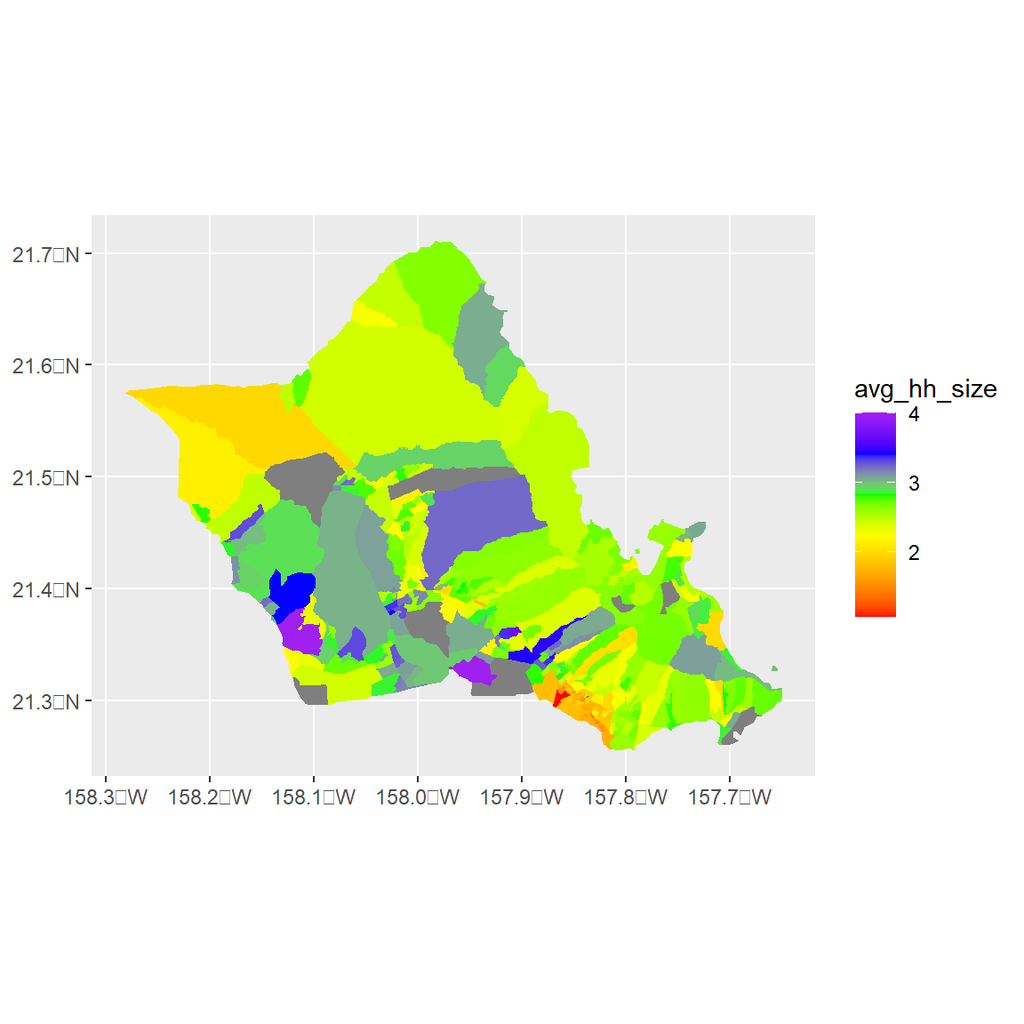

```r
hh_size_map +
  scale_fill_gradientn(colors = c("red",
                                  "orange",
                                  "yellow",
                                  "green",
                                  "blue",
                                  "purple"))
```

The `RColorBrewer` package offers a bunch of pre-defined palettes that can be useful for continuous data. You can view the options with the function `display.brewer.all()

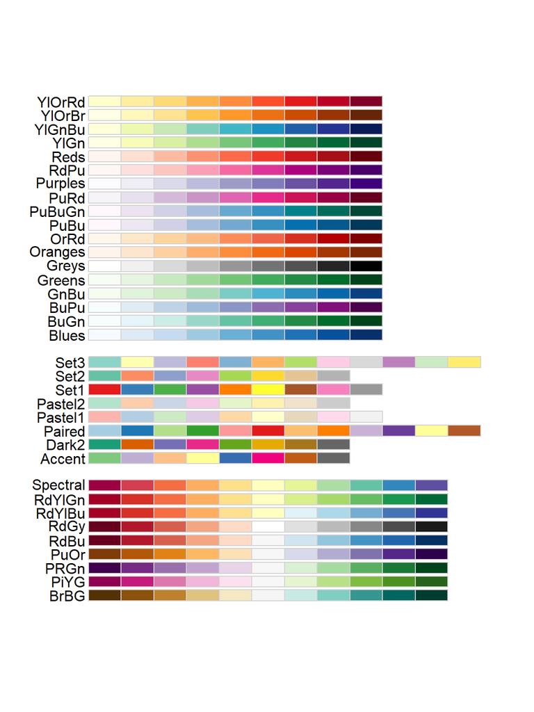

```r
library(RColorBrewer)

display.brewer.all()
```

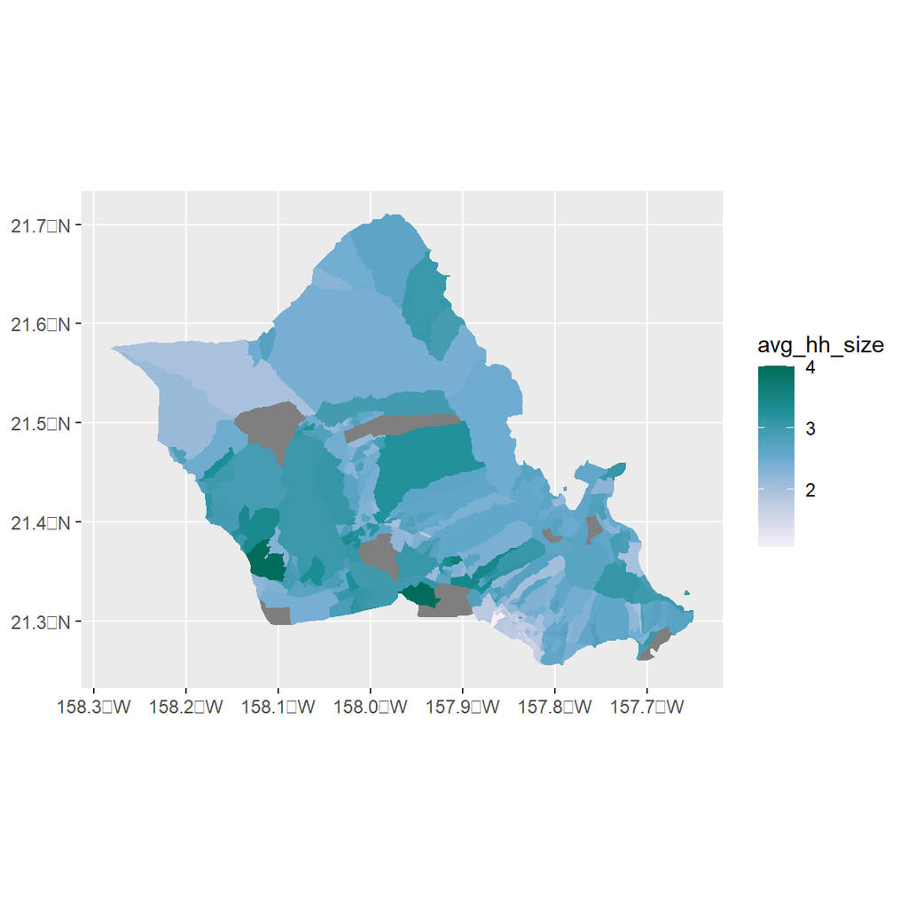

```r
map_palette <- brewer.pal(5, "PuBuGn")

hh_size_map +
  scale_fill_gradientn(colors = map_palette)
```

The last group of colors are diverging palettes, which range from dark to light to dark colors.

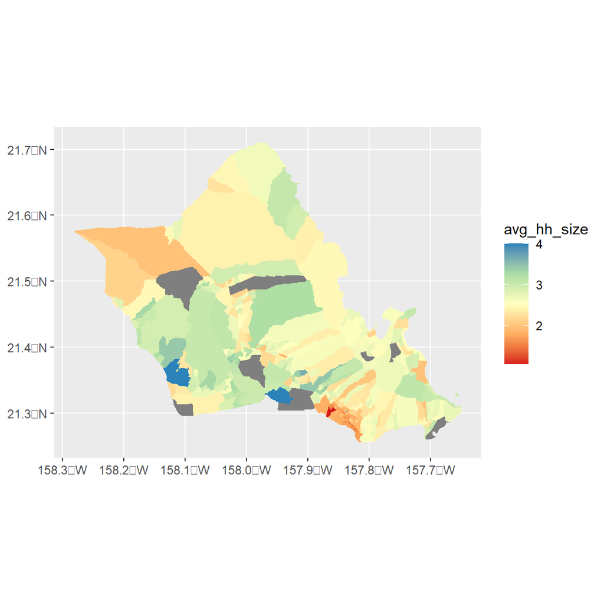

```r
map_palette <- brewer.pal(5, "Spectral")

hh_size_map +
  scale_fill_gradientn(colors = map_palette)
```

The middle group are qualitative palettes which work well for categorical variables, but would be confusing for a continuous color ramp.

There are some other fun package that define color palettes, including wesanderson (colors inspired by Wes Anderson films), [PNWColors](https://jakelawlor.github.io/portfolio/pnwcolors/) (colors inspired by the package author’s photos of the Pacific Northwest), [MetBrewer](https://github.com/BlakeRMills/MetBrewer/tree/main) (inspired by works at the Metropolitan Museum of Art), and [MexBrewer](https://paezha.github.io/MexBrewer/) (inspired by works of Mexican muralists). These four packages are structured similarly. Some of the available palettes don’t work well for continuous variables (the order of the colors isn’t intuitive), but some work well.

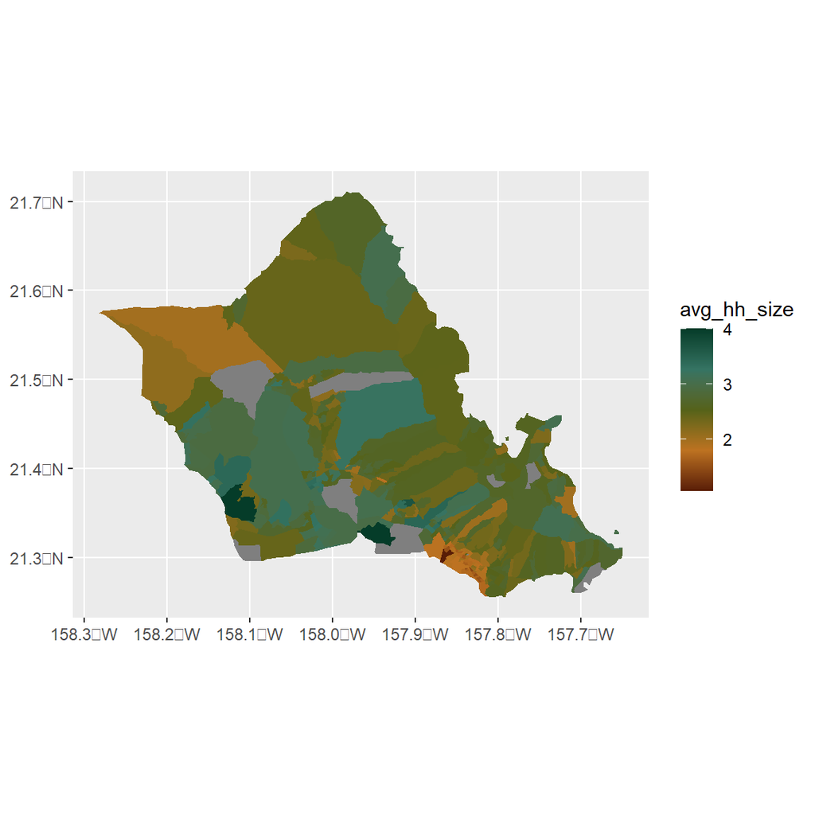

```r
library(MetBrewer)

degas_contin <- met.brewer(name = "Degas", n = 5, type = "continuous")

hh_size_map +
  scale_fill_gradientn(colors = degas_contin)
```

# Download census tract data

You’ll need to download several tract-level variables from the census. You’ll find the `tidycensus` package super useful for this.

Assuming you’ve already [defined a list of variables](https://gsd-ses-5394-sp2023.github.io/skills/a2.html#list-census-variable-names) and saved it as a [character vector](https://r4ds.had.co.nz/vectors.html) called `vars`, you can use the `get_acs()` function in the `tidycensus` package to download the data.

```r
hh_vars = c(no_veh = "B08201_002",
            total_hhs = "B08201_001",
            hh_1person = "B08201_007",
            hh_2person = "B08201_013",
            hh_3person = "B08201_019",
            hh_4person_plus = "B08201_025",
            inc_lt_10k = "B19001_002",
            inc_btw_10k_15k = "B19001_003",
            inc_btw_15k_20k = "B19001_004",
            inc_btw_20k_25k = "B19001_005",
            inc_btw_25k_30k = "B19001_006",
            inc_btw_30k_35k = "B19001_007",
            inc_btw_35k_40k = "B19001_008",
            inc_btw_40k_45k = "B19001_009",
            inc_btw_45k_50k = "B19001_010",
            inc_btw_50k_60k = "B19001_011",
            inc_btw_60k_75k = "B19001_012",
            inc_btw_75k_100k = "B19001_013",
            inc_btw_100k_125k = "B19001_014",
            inc_btw_125k_150k = "B19001_015",
            inc_btw_150k_200k = "B19001_016",
            inc_gt_200k = "B19001_017")
```

I’ll use the `get_acs()` function from the `tidycensus` package. `geography = 'tract'` means I want tract-level data. I’ll also specify the state and county (or counties - I can provide a list of all the counties in my study area here if there is more than one). In most cases, I’ll set `output = wide` because I want each variable in its own column. You’ll also need the zone/tract boundaries at some point, so you should get those at the same time by setting `geometry = TRUE`.

In this case, I’m also filtering out tracts with empty geometries and one specific tract that represents a set of small islands that have zero population and zero employment - it may or may not be necessary for you to do something like this for your study area.

```r
library(tidycensus)

census <- get_acs(geography = "tract",
                              state = "HI",
                              county = "003",
                              variables = hh_vars,
                              output = "wide",
                              geometry = TRUE) %>%
  filter(!st_is_empty(geometry)) %>%
  filter(GEOID != "15003981200") # small islands with no jobs or hhs
```

You can also get boundaries from the `tigris` package. These will be the same as the ones returned by `tidycensus`, but they also come with a variable called `ALAND` which indicates the total land area of the tract (in square meters).

```r
library(tigris)

honolulu_areas <- tracts(state = "HI",
                         county = "Honolulu") %>%
  select(GEOID, ALAND) %>%
  st_drop_geometry()
```

# Download employment data

The Longitudinal Employer-Household Dynamica (LEHD) dataset is a great source of census-block level employment data by industry.

Select the appropriate state from the drop-down menu, and select ‘Workplace Area Characteristics (WAC)’ from the ‘Type’ drop-down menu. Then click the ‘View Files’ button to see a list of available files. You can read about the file naming conventions [here](https://lehd.ces.census.gov/data/lodes/LODES7/LODESTechDoc7.5.pdf). The one you want is called [xx]_wac_S000_JT00_2019.csv.gz, where xx is the two-letter postal code for the state. Right-click on the link for the file and select ‘copy link address’.

So you can use `select()` to keep those (and use `mutate()` to calculate service employment) and drop everything else (make sure you also keep w_geocode, which has the GEOID for the block).

This data is at the census block level, not the tract level. You’ll need to collapse it to the tract level (see the “Collapse data” topic).

```r
library(tidyverse)

lehd_blocks <- read_csv('https://lehd.ces.census.gov/data/lodes/LODES7/ny/wac/ny_wac_S000_JT00_2019.csv.gz', show_col_types = FALSE) %>%
  rename(total_emp = C000) %>%
  mutate(basic_emp = CNS01+CNS02+CNS03+CNS04+CNS05+CNS06+CNS08+CNS09) %>%
  rename(retail_emp = CNS07) %>%
  mutate(service_emp = total_emp - basic_emp - retail_emp) %>%
  select(w_geocode, total_emp, basic_emp, retail_emp, service_emp)
```

# Find census variables

You’ll need to search for the names of the variables you want to include in your analysis.

If you’ve already loaded the `tidycensus` package, you can type `View(load_variables(2019, "acs5"))`* into your console to interactively search for variables that you’d like to include in your analysis. That will open a table of all the available variables in your viewer. Here’s what you’ll see if you start searching for variables that have to do with vehicles:

[figure not shown]

You’ll see that the table has three columns.

- The first column is the variable name. The variable name will have two parts: the part before the underscore tells you which table the variable is a part of, that the part after the underscore tells you which row the variable is in.
- The second column is the variable label. This describes that specific variable.
- The third column, called “concept,” is the name of the table identified in the first part of the variable name.

Many tables are cross-tabulations that present the number of people, homes, or households in each combination of two categories. Many values can be found in multiple tables. For example, you can find the total number of workers who commute to work by car in B08006 (Sex of worker by means of transportation to work) and B08101 (Means of transportation to work by age).

* *The first argument (`2019`) indicates that you want the variables that are available for 2019 and the second argument (`"acs5"`) indicates that you want variables that are included in the 5-year sample of the American Community Survey. The 5-year sample is from survey respondents pooled over a 5-year period. An alternative is `"acs1"`, which would give you just the households who completed the survey in 2019 (which is a much smaller sample, so those estimates would have more uncertainty associated with them). You could also specify `"sf1"` instead of `"acs5"` or `"acs1"` if you wanted data from the decennial census. The decennial census is meant to include everyone, so there is no sampling error, but fewer variables are available. The 2020 decennial census hasn’t been released yet, but you can get a very limited set of variables from the redistricting data – use `"pl"` rather than `"sf1"` in that case.*

# Join two data frames

If you have employment data in one dataframe (see the “Download employment data” topic) and population data in another (see the “Download census tract data” topic), you’ll want to combine them into a single dataframe.

In these examples, I know my population data only includes tracts in my study area because I filtered to to my study area boundary. My employment data is for the whole state. I’ll do a left join, with the population data on the left (i.e. listed first), which wil drop all the rows of the employment data that aren’t include in my population data.

```r
zones <- left_join(census, lehd_tracts)
```

A quick review on what the pipe (`%>%`) does. It takes the output of the function before it and enters it as the first argument in the function after it. So the line in the chunk above this is exactly the same as the following lines with a pipe:

```r
zones <- census %>%
  left_join(lehd_tracts)
```

# List census variable names

Once you’ve identified the census variable you want to include in your analysis (see the “Find census variables” topic), you can create a list of them. The function `c()` lets you list a bunch of items so you can pass them into another function (for example, the `get_acs()` function - see the “Download census tract data” topic) as a single argument. You could just list all the variable names you’ve identified like this:

```r
vars <- c('B08203_001',
          'B08203_002',
          'B08201_007',
          'B08201_013',
          'B08201_019',
          'B08201_025',
          'B19001_002',
          'B19001_003',
          'B19001_004',
          'B19001_005',
          'B19001_006',
          'B19001_007',
          'B19001_008',
          'B19001_009',
          'B19001_010',
          'B19001_011',
          'B19001_012',
          'B19001_013',
          'B19001_014',
          'B19001_015',
          'B19001_016',
          'B19001_017')
```

But remember that you don’t only want computers to be able to read your code. You want humans (including your future self) to be able to read it too. To that end, you can also define more intelligible variable names when you list your variables.

```r
vars <- c(total_hhs = 'B08203_001',
          no_veh = 'B08203_002',
          hh_1person = 'B08201_007',
          hh_2person = 'B08201_013',
          hh_3person = 'B08201_019',
          hh_4person_plus = 'B08201_025',
          inc_lt_10k = 'B19001_002',
          inc_btw_10k_15k = 'B19001_003',
          inc_btw_15k_20k = 'B19001_004',
          inc_btw_20k_25k = 'B19001_005',
          inc_btw_25k_30k = 'B19001_006',
          inc_btw_30k_35k = 'B19001_007',
          inc_btw_35k_40k = 'B19001_008',
          inc_btw_40k_45k = 'B19001_009',
          inc_btw_45k_50k = 'B19001_010',
          inc_btw_50k_60k = 'B19001_011',
          inc_btw_60k_75k = 'B19001_012',
          inc_btw_75k_100k = 'B19001_013',
          inc_btw_100k_125k = 'B19001_014',
          inc_btw_125k_150k = 'B19001_015',
          inc_btw_150k_200k = 'B19001_016',
          inc_gt_200k = 'B19001_017')
```

# Write data to a file

To write spatial data, I suggest saving it to a geojson file using `st_write()`. st_write() can write spatial data to few different file formats, including ESRI shapefiles (useful if you want to bring your data into ArcGIS). I personally like the geojson format because I find it easy to work with.

```r
st_write(zone_boundaries, "zones/boundaries.geojson", append = FALSE)
```

To write tabular data, it makes sense to save it to a csv file using `write_csv()`.

```r
write_csv(final_data, "existing/data/zone_data.csv", append = FALSE)

write_csv(zones_new, "alternative/data/zone_data.csv", append = FALSE)
```

# Write figures to a file

Creating maps and charts in RMarkdown is great, but you’ll eventually want to save them as files you can include in a report or presentation. ggsave() will save the most recent plot to a filename you specify. That means you can call ggsave() immediately after plotting. You can specify the size of the image in inches (`units = "in"`), centimeters (`units = "cm"`), milimeters (`units = "mm"`), or pixels (`units = "px"`). You can also set the image resolution using the dpi argument, which can be a number (the number of dots per square inch) or one of three strings: `"retina"` (320 dpi), `"print"` (300 dpi - this the default), or `"screen"` (72 dpi). ggsave() can save to most common image file types. There is no need to specify a resolution if you want it to be 300 dpi (because that’s the default) or if you’re saving to a vector file type (pdf or svg, for example).

```r
hh_size_map

ggsave("images/hh_sizes_existing.png",
       height = 4.25, width = 6.5, units = "in")
```

If you don’t want to save the most recent plot, you can also specify the plot directly.

```r
ggsave("images/hh_density_existing.png", plot = dens_map,
       height = 4.25, width = 6.5, units = "in")
```